```python
!jupyter nbconvert --template=nbextensions --to=html MAS_HW6_Tommy_Maaiveld-Copy1.ipynb
```

# Multi-Agent Systems Homework 6

Thomas Maaiveld (t.m.maaiveld@student.vu.nl); 2528586

# 1 $\enspace$ Multi-Armed Bandits

## 1.1 Thompson Sampling for single bandit

Consider a bandit that for each pull of the arm, produces a binary reward: $r = 1$ (with probability $p$) or $r = 0$ (with probability $1-p$). We model our uncertainty about the actual (but unknown) value $p$ using a beta-distribution (cf. https://en.wikipedia.org/wiki/Beta_distribution). This is a probability distribution on the interval $[0, 1]$ which depends on two parameters: $\alpha, \beta \geq 1$. The explicit distribution is given by (for $\alpha, \beta$ integers!):

\begin{equation} B(x;\alpha,\beta) = \frac{(\alpha + \beta - 1)!}{(\alpha - 1)!(\beta - 1)!}x^{\alpha - 1}(1-x)^{\beta - 1} \ \ \ \ (\text{for} \ 0 \leq x \leq 1) \end{equation}

The parameters $\alpha$ and $\beta$ determine the shape of the distribution:

- If $\alpha = \beta = 1$ then we have the uniform distribution;
- If $\alpha = \beta$ the distribution is symmetric about $x = \frac{1}{2}$.
- If $\alpha > \beta$ the density is right-leaning (i.e. concentrated in the neighbourhood of 1). In fact, one can compute the mean explicitly:

\begin{equation} X \sim B(x;\alpha,\beta) \enspace \implies \enspace \mathbb{E}[X] = \frac{\alpha}{\alpha + \beta} \end{equation}

Larger values of $\alpha$ and $\beta$ produce a more peaked distribution. This follows from the formula for the variance:

\begin{equation} X \sim B(x;\alpha,\beta) \enspace \implies \enspace Var(X) = \frac{\alpha\beta}{(\alpha+\beta)^2(\alpha + \beta + 1)} \end{equation}

$\textbf{Thompson update rule}$ Assume that we don't know the success probability $p$ for the bandit. The Thompson update rule for a single bandit proceeds as follows:

- Initialise $\alpha = \beta = 1$ (resulting in a uniform distribution, indicating that all values for $p$ are equally likely). Now repeat the following loop:
  1. Sample from the bandit and get reward $r$ (either 1 or 0);
  2. Update the values for $\alpha$ and $\beta$ as follows:

\begin{equation} \alpha \leftarrow \alpha + r \qquad \beta \leftarrow \beta + (1 - r) \end{equation}

$\textbf{Questions}$

- Make several plots of the Beta-density to illustrate the properties (dependence on the parameters) outlined above.

The following plots show the probability density of $B(x;\alpha,\beta)$ for the different combinations of $\alpha$ and $\beta$ shown in the legend. Noticeable patterns are that higher values for $\alpha$ result in a right-leaning distributions, while higher values for $\beta$ produce a left-leaning distribution. Combinations can be mixed to produce different distributions, while setting either parameter to 1 while the other is greater than 1 leads to a sloped probability distribution function in either direction.

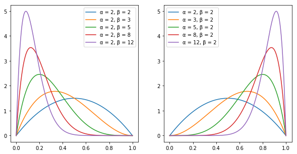

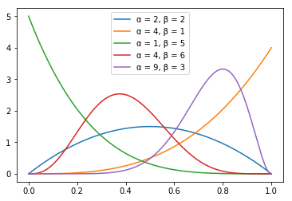

- Implement the Thompson update rule and show experimentally that the Beta-density increasingly peaks at the correct value for $p$. Plot both the evolution and the mean and variance over (iteration) time.

The Thompson update rule was implemented and tested with a bandit with a true probability $p=0.3$ of sampling reward $1$. The following two plots show the evolution of the mean over generations, both for the expected value and theoretical variance derived from the beta distribution for updated parameters $\alpha$ and $\beta$, as well as for the values sampled from the bandit in the code above. The expected value for the mean derived for parameters $\alpha$ and $\beta$ closely follows the calculated sample mean for generations of the algorithm (each generation being a sampled reward from the bandit) and approaches it in the limit. The same holds for the variance.

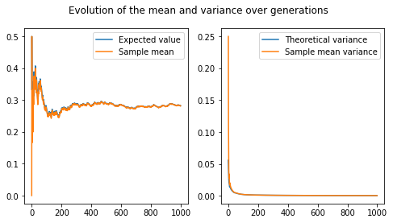

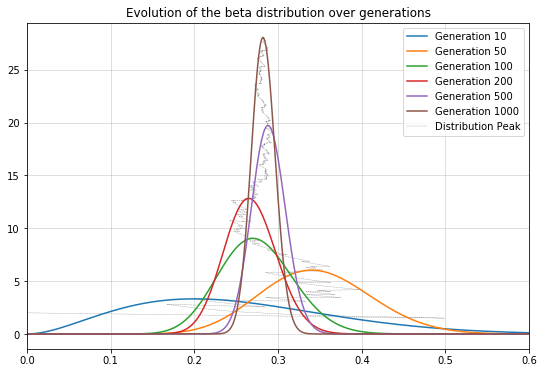

[video not shown]

$\textbf{Thompson Sampling}$ Suppose we have a 2-bandit problem. The first one delivers a reward $r = 1$ with (unknown!) probability $p_1$, while the second one does so with (unknown!) probability $p_2$. For each bandit ($k = 1,2$), the uncertainty about the corresponding $p_k$ is modelled using a Beta-distribution with coefficients $\alpha_k, \beta_k$. Thompson sampling now tries to identify the bandit that delivers the maximal output and proceeds as follows:

- Initialise all parameters to 1: $\alpha_k = 1 = \beta_k$; Now repeat the following loop:
1. Sample the value $u_k$ for each of the two Beta-distributions:

\begin{equation} u_k \sim B(x;\alpha_k,\beta_k) \end{equation}

1. Determine the max: $k_m = \text{argmax}\{u_1,u_2\}$
2. Sample the corresponding bandit and get reward $r$ (either 1 or 0);
3. Update the corresponding parameters: $\alpha_{k_m}$ and $\beta_{k_m}$ as follows:

\begin{equation} \alpha_{k_m} \rightarrow \alpha_{k_m} + r \quad \enspace \text{and} \enspace \quad \beta_{k_m} \rightarrow \beta_{k_m} + (1 - r) \end{equation}

$\textbf{Questions}$

- Write code to implement Thompson sampling for the above scenario;

The setup was implemented using two bandits with true probabilities $p=0.45$ and $p=0.55$. 1000 iterations of the algorithm were used to find the modeled probability distributions of the bandits.

The distribution of the inferior bandit ($p = 0.45$) is updated less frequently and takes longer to approach the proper distribution. This is presumably because the $\text{argmax}(u_k)$ will rarely choose $u_k$ for an inferior bandit $k$ if a better sampled $u_k$ is available, meaning its parameters $\alpha_k$ and $\beta_k$ are updated less often.The animation below shows the development of the distribution of $p$ for both bandits. The vertical lines show the actual values for $p_k$ for each of the $k$ bandits. </font>

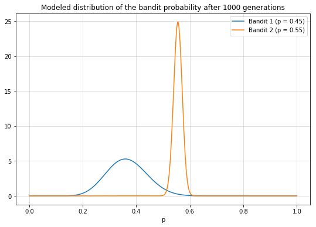

[video not shown]

- Perform numerical experiments in which you compare Thompson sampling with the UCB and $\epsilon$-greedy approach. Define some performance measures and discuss the performance of each algorithm with respect to these measures.

A setup with two bandits with true probabilities $p=0.3$ and $p=0.7$ was used to show the difference between the three approaches. 20 runs of 2000 episodes were conducted to generate the results. The plots for the average cumulative reward and regret over time for the Thompson sampling, $\epsilon$-greedy and UCB agents are given below, for parameter settings $\epsilon = 0.1$ and $c = 2$. In terms of reward, Thompson performs best, followed by $\epsilon$-greedy and UCB.

In terms of regret, $\epsilon$-greedy accumulates linear regret over time, as its exploration is fixed. It quickly finds the better bandit of the two, but is forced to choose the other bandit because of the exploration mechanism, meaning it will linearly accumulate regret over time. Thompson and UCB instead follow a logarithmic regret curve, with Thompson acquiring the least regret in the limit.

Some small performance increase can be achieved by tweaking parameter $c$, but Thompson performs best in terms of regret on the long term. </font>

```python
### INITIALIZATION ###

def e_greedy(Q, epsilon=0.1):
    if random.random() < epsilon:
        return random.randint(0,len(Q)-1)
    return np.random.choice(np.where(Q == Q.max())[0])


def UCB1(Q, choices):
    upper_bounds = [Q_a + conf_bound(len(choices), choices.count(j)) for j, Q_a in enumerate(Q)]
    upper_bounds = np.array(upper_bounds)

    return e_greedy(upper_bounds, epsilon=0)


def conf_bound(t, times_chosen, c=2):
    return sqrt(c * log(t) / times_chosen)


def e_greedy_bandit(p, MAX_IT, epsilon=0.1):

    choices = []
    rewards = []
    Q = np.array([0.5,0.5])

    for i in range(MAX_IT):

        k = e_greedy(Q)
        reward = sample_bandit(p[k])

        choices.append(k)
        rewards.append(reward)

        Q[k] += (1 / (choices.count(k) + 1)) * (reward - Q[k])

    return choices, rewards


def UCB_bandit(p, MAX_IT, c):

    choices = [0,1]
    rewards = [0,0]
    Q = [0,0]

    for i in range(MAX_IT-2):

        k = UCB1(Q, choices)
        reward = sample_bandit(p[k])

        choices.append(k)
        rewards.append(reward)

        Q[k] += 1 / (choices.count(k) + 1) * (reward - Q[k])

    return choices, rewards


### EXPERIMENT DESIGN ###

def bandit_experiment(p, c, max_it, runs):

    thompson_rewards_df = pd.DataFrame(0, index=np.arange(max_it), columns=np.arange(runs))
    e_greedy_rewards_df = thompson_rewards_df.copy()
    UCB_rewards_df      = thompson_rewards_df.copy()

    thompson_choices_df = thompson_rewards_df.copy()
    e_greedy_choices_df = thompson_rewards_df.copy()
    UCB_choices_df      = thompson_rewards_df.copy()

    thompson_regret_df  = thompson_rewards_df.copy()
    e_greedy_regret_df  = thompson_rewards_df.copy()
    UCB_regret_df       = thompson_rewards_df.copy()

    for run in range(runs):

        params, choices, rewards = thompson_sampling(p, max_it)
        thompson_choices_df.iloc[:,run] = choices
        thompson_rewards_df.iloc[:,run] = rewards

        choices, rewards = e_greedy_bandit(p, max_it)
        e_greedy_choices_df.iloc[:,run] = choices
        e_greedy_rewards_df.iloc[:,run] = rewards

        choices, rewards = UCB_bandit(p, max_it, c)
        UCB_choices_df.iloc[:,run] = choices
        UCB_rewards_df.iloc[:,run] = rewards

    opportunity_gap = max(p) - min(p)

    thompson_regret_df  = (1-thompson_choices_df) * opportunity_gap
    e_greedy_regret_df  = (1-e_greedy_choices_df) * opportunity_gap
    UCB_regret_df       = (1-UCB_choices_df) * opportunity_gap

    return [thompson_rewards_df, e_greedy_rewards_df, UCB_rewards_df,
            thompson_regret_df, e_greedy_regret_df, UCB_regret_df]


### VISUALIZATION ###

def plot_results(data, labels, title, iterations=200, method='cumulative', add=False, add_label=" "):
    """Plots experiment results, averaged over runs."""

    data = [stat[:iterations] for stat in data]

    for i, entry in enumerate(data):
        if method == 'mean':
            plt.plot(entry.mean(axis=1), label=labels[i])
        elif method == 'cumulative':
            plt.plot(entry.mean(axis=1).expanding().sum(), label=labels[i])
        else:
            plt.plot(entry, label=labels[i])

    if not add_label == " ":
        plt.plot(add.expanding().sum(), add_label)

    plt.legend()
    plt.title(title)
    plt.show()
```

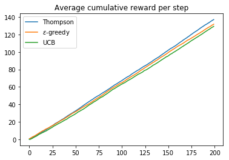

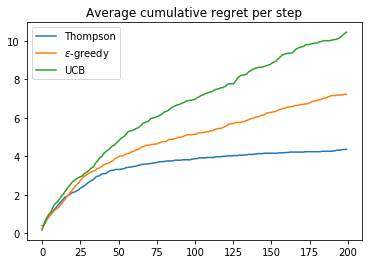

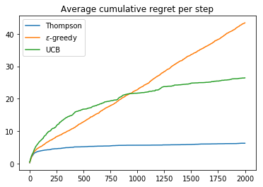

```python
c = 2
p = [0.3, 0.7]
MAX_IT = 2000
runs = 20

# small_data = bandit_experiment(p, c, 200, runs)
data = bandit_experiment(p, c, MAX_IT, runs)
labels = ["Thompson", "$\epsilon$-greedy", "UCB"]

# print(small_data)

# processing the results
plot_results(data[0:3], labels[0:3], "Average cumulative reward per step")
plot_results(data[3:], labels[0:3], "Average cumulative regret per step")
plot_results(data[3:], labels[0:3], "Average cumulative regret per step", iterations=2000)
```

# 2 $\enspace$ Reinforcement Learning: Cliff Walking

Consider the cliff-walking example (Sutton & Barto, ex. 6.6 p.108). Assume that the grid has 10 columns and 5 rows (above or in addition to the cliff). This is a standard undiscounted, episodic task, with start and goal states, and the usual actions causing movement up, down, right and left. Reward is $-1$ on all transitions except:

- the transition to the terminal goal state (G) which has an associated reward of $+20$;
- transitions into the region marked $\textit{The Cliff}$. Stepping into this region incurs a "reward" of $-100$ and also terminates the episode.

[figure not shown]

$\textbf{Questions}$

1. Use both SARSA and Q-Learning to construct an appropriate policy. Do you observe the difference between the SARSA and Q-learning policies mentioned in the text (safe versus optimal path)? Discuss.

$\epsilon$ was set to $0.1$ for both approaches, and gridworld experiments were conducted. The optimal policies, accumulated average reward per time step and episode time per time step shown below were obtained by using the mode over all policies (a 'majority vote') and averaging over twenty episodes respectively. Each run consisted of 10000 iterations of the game, of which the first 200 are shown in the plot and the rest are used to find the optimal policy. Some areas remain unexplored even after 10000 iterations, since the probability of visiting these is so low.

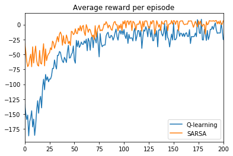

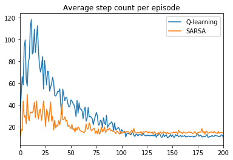

```
Average optimal policy (Q-learning)
[['→' '↑' '↑' '↑' '←' '→' '↓' '↑' '↑' '→']
 ['↓' '↑' '↓' '↓' '↓' '↓' '↓' '↓' '↓' '↓']
 ['↓' '↓' '↓' '→' '↓' '↓' '↓' '↓' '↓' '↓']
 ['↓' '↓' '→' '↓' '→' '↓' '↓' '↓' '↓' '↓']
 ['→' '→' '→' '→' '→' '→' '→' '→' '→' '↓']
 ['↑' '×' '×' '×' '×' '×' '×' '×' '×' '⚑']]

Average optimal policy (SARSA)
[['↓' '↑' '↓' '↓' '↓' '↓' '↓' '↓' '↓' '↓']
 ['↓' '↓' '↓' '↓' '↓' '↓' '↓' '↓' '↓' '↓']
 ['↓' '↓' '↓' '→' '↓' '↓' '↓' '↓' '↓' '↓']
 ['→' '→' '→' '→' '→' '→' '→' '→' '→' '↓']
 ['↑' '↑' '↑' '↑' '↑' '↑' '↑' '↑' '→' '↓']
 ['↑' '×' '×' '×' '×' '×' '×' '×' '×' '⚑']]
```

```python
dims = (10,6)
A = [0,1,2,3]
epsilon = [0.1]
runs = 20
MAX_IT = 10000

data = cliffworld_experiment(dims, A, epsilon, MAX_IT, runs)[0]

labels = ["Q-learning", "SARSA"]

plot_results(data[0:2], labels, "Average reward per episode")
plot_results(data[2:4], labels, "Average step count per episode")

print_moves(data[4], "Average optimal policy (Q-learning)")
print_moves(data[5], "Average optimal policy (SARSA)")
```

1. Try different values for $\epsilon$ (parameter for $\epsilon$-greedy policy). How does the value of $\epsilon$ influence the result? Discuss.

Clearly, introducing increasing amounts of stochasticity to this environment show an advantage SARSA has over Q-learning. Its accumulated reward also decreases as it is forced to take a longer path, but this is notably less than the detriment to Q-learning's performance. </font>

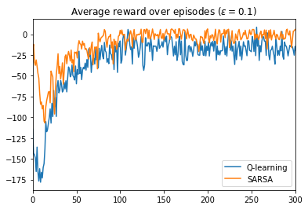

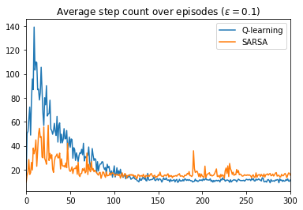

[output not shown]

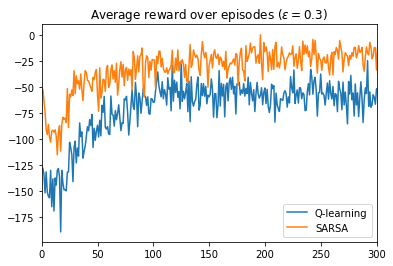

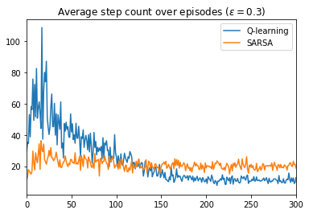

[output not shown]

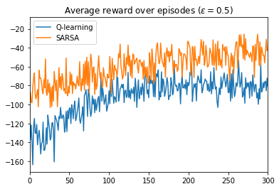

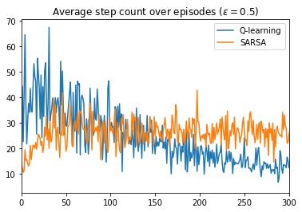

[output not shown]

```python
dims = (10,6)
A = [0,1,2,3]
epsilon = [0.1, 0.3, 0.5]
MAX_IT = 1000
runs = 20

results = cliffworld_experiment(dims, A, epsilon, MAX_IT, runs)

for i, result in enumerate(results):
    plot_results(result[0:2], labels,
                 "Average reward over episodes ($\epsilon = {}$)".format(epsilon[i]), iterations=300)

    plot_results(result[2:4], labels,
                 "Average step count over episodes ($\epsilon = {}$)".format(epsilon[i]), iterations=300)

    print_moves(result[4], "Aggregated optimal policy (Q-learning)")
    print_moves(result[5], "Aggregated optimal policy (SARSA)")
```